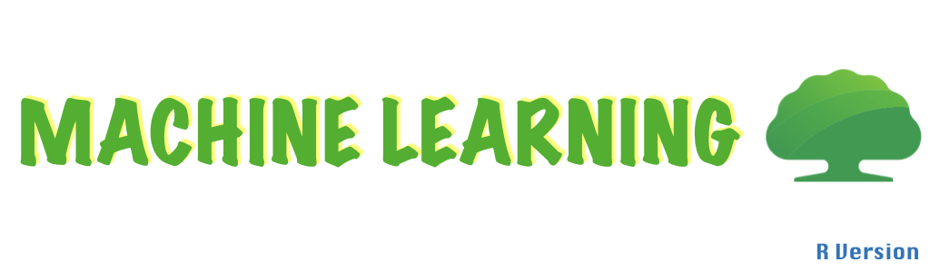

本教材輔助AI平台專用，如有任何問題請回報

資料倉儲科 李嘉桓 #2134

Classification Model 分類模型

# **使用說明**

- 此平台建議有初階R語言能力者使用，初學者建議使用國泰學習網[R與Python教育訓練](https://cathay.elearn.com.tw/dist/index.html#/learning-passport/incomplete-courses/course-info/9608351?mid=5952)完成初階課程。
- 請將語法複製至本機Rstudio或server版上使用執行(不同環境kernel可能會有所不同)，將要執行的程式碼選取，按鍵盤Ctrl+Enter執行語法。
- 每一台電腦的R版本不一樣，預設套件也不同，若跳出缺少套件的訊息，請自行安裝相關套件。
- 建議將文件建立在R根目錄下開一個新資料夾當工作環境，可以使用語法getwd()確認工作路徑。
- 本教材以 R version 3.4.3 進行示範。
- 本章節會教學多個分類模型演算法，並使用 Step1 的 TrainData_Fill_ONE.rds 當訓練資料進行示範，若缺少該檔案的麻煩回去 Step1 執行。
- 每個演算法接受的資料品質不一致，有的演算法能吃缺失值，有的要全部轉為 one-hot 編碼，實務運用時請自行根據演算法調整。

# 1. **資料載入**

```r
# 讀取 rds 資料
TrainData = readRDS("TrainData_Fill_ONE.rds")
TestData = readRDS("TestData_Fill_ONE.rds")
cat('訓練資料筆數：',dim(TrainData)[1],'訓練資料欄位數',dim(TrainData)[2])
```

```
## 訓練資料筆數： 40000 訓練資料欄位數 140
```

```r
cat('測試資料筆數：',dim(TestData)[1],'訓練資料欄位數',dim(TestData)[2])
```

```
## 測試資料筆數： 60000 訓練資料欄位數 140
```

```r
# head(TrainData) # 可以觀察資料樣貌
```

- 因演算法眾多，建立儲存模型及結果的資料夾，若沒有則創一個。

```r
if(!dir.exists(file.path(getwd(), "Model"))) dir.create(file.path(getwd(), "Model"))
if(!dir.exists(file.path(getwd(), "Result"))) dir.create(file.path(getwd(), "Result"))
```

# 2. **資料設定**

## 2.1 平行運算環境

- R 一般為單核運算，為了提高運算效率，設定多核運行環境， doParallel 套件支援多核運行環境，詳細可以看 [doParallel](https://cran.r-project.org/web/packages/doParallel/vignettes/gettingstartedParallel.pdf) 。

```r
library('doParallel')
# 建立多核運算環境
cl<-makeCluster(4) # 自行根據硬體設備設定
registerDoParallel(cl)
# getDoParWorkers() # 確認目前使用core數
# stopCluster(cl) # 不使用時可以用此語法關閉多核運行
```

## 2.2 資料集設定

- 設定目標欄位 (Y變數) 及特徵欄位 (X變數)，以及辨識 key 欄位。

```r
TargetColumn = 'APPROVE'
ID_column = 'NO_ID'

Train_Y = TrainData[[TargetColumn]]
Train_X = TrainData[,-which(colnames(TrainData) %in% c(TargetColumn,ID_column))]
Test_Y = TestData[[TargetColumn]]
Test_X = TestData[,-which(colnames(TestData) %in% c(TargetColumn,ID_column))]
```

## 2.3 載入模型評估套件

- 載入模型評估相關套件，當作比較演算法優劣的依據，一般來說會觀察 Accuracy、Precision、Recall、F1_Score 等。
- 分類模型常用的還有 ROC AUC 來評估模型好壞，大多用於二元分類上，詳細可以看 [Receiver operating characteristic](https://en.wikipedia.org/wiki/Receiver_operating_characteristic)。

```r
library('MLmetrics')
library('pROC')
```

# 3. **模型訓練**

- R 的模型語法相當多種，如果要以最通用的套件來建模， R 的 caret 類似 python 的 sklearn ，包含相當多機器學習的函數，功能非常強大，此教材將以 caret 為教學示範，詳細可以看 [caret](https://topepo.github.io/caret/index.html)。
- 但 caret 也是有缺點，因為整合了各家套件，所以速度略慢，使用前必須先安裝各個演算法原生的套件，熟悉 R 語言的人可以改用原生的演算法函數，速度會快很多。
- 模型訓練時，我們會做交叉驗證 Cross-validation，目的在於得到可靠穩定的模型，減少 Overfitting 的風險。
- 交叉驗證我們使用 caret 的 trainControl 函數來做到 K-fold cross-validation 功能，以 4 個 fold 為例語法如下，代表有 75% 資料拿來訓練，25% 的資料拿來驗證。

```r
library('caret')
fitControl <- trainControl(## 4-fold CV
                           method = "cv",
                           number = 4)
```

## 3.1 Generalized linear model

- 迴歸模型為最常見的預測模型，在分類問題上我們使用 Logistic Regression 處理。
- Regression 的函數很多，以下用 glmnet 函數示範，此函數可自定義 alpha 及 lambda 值，做到 L1、L2 的功效，應用相當廣泛，詳細可以看 glmnet。
- 本教材的目標函數只有兩個元素，為二元分類的問題，可以使用 binomial 方法處理，若目標元素超過 2 個，則要使用 multinomial 方法處理。

```r
model_glm = train(x = Train_X,
                  y = Train_Y,
                  method = "glmnet",
                  trControl = fitControl,
                  family="binomial" # 根據實務自行更換
                  )

model_glm
```

```
## glmnet
##
## 40000 samples
##   138 predictor
##     2 classes: 'N', 'Y'
##
## No pre-processing
## Resampling: Cross-Validated (4 fold)
## Summary of sample sizes: 30000, 30000, 30000, 30000
## Resampling results across tuning parameters:
##
##   alpha  lambda        Accuracy  Kappa
##   0.10   0.0002744942  0.739600  0.4376695
##   0.10   0.0027449422  0.739400  0.4365275
##   0.10   0.0274494216  0.733925  0.4189315
##   0.55   0.0002744942  0.739825  0.4380757
##   0.55   0.0027449422  0.738600  0.4337104
##   0.55   0.0274494216  0.721250  0.3785558
##   1.00   0.0002744942  0.739750  0.4378100
##   1.00   0.0027449422  0.738100  0.4315975
##   1.00   0.0274494216  0.703950  0.3255107
##
## Accuracy was used to select the optimal model using the largest value.
## The final values used for the model were alpha = 0.55 and lambda
##  = 0.0002744942.
```

- 觀察測試資料預測結果。

```r
Test_pred = predict(model_glm,Test_X,type = "raw") # raw 代表回傳預測結果
Test_pred_score = predict(model_glm,Test_X,type = "prob")[,2] # prob [,2]代表為Y的機率，計算AUC用
pred_CM = confusionMatrix(Test_pred,Test_Y, mode = "prec_recall",positive = "Y") # 計算混淆矩陣
pred_AUC = auc(as.integer(Test_Y)-1,Test_pred_score) # 計算AUC，需要轉數值
performance_glm = list(pred_CM,pred_AUC)
print(performance_glm)
```

```
## [[1]]
## Confusion Matrix and Statistics
##
##           Reference
## Prediction     N     Y
##          N 13499  5140
##          Y 10487 30874
##
##                Accuracy : 0.7396
##                  95% CI : (0.736, 0.7431)
##     No Information Rate : 0.6002
##     P-Value [Acc > NIR] : < 2.2e-16
##
##                   Kappa : 0.4363
##
##  Mcnemar's Test P-Value : < 2.2e-16
##
##               Precision : 0.7465
##                  Recall : 0.8573
##                      F1 : 0.7980
##              Prevalence : 0.6002
##          Detection Rate : 0.5146
##    Detection Prevalence : 0.6894
##       Balanced Accuracy : 0.7100
##
##        'Positive' Class : Y
##
##
## [[2]]
## Area under the curve: 0.7989
```

- 觀察模型前 20 主要影響成分。

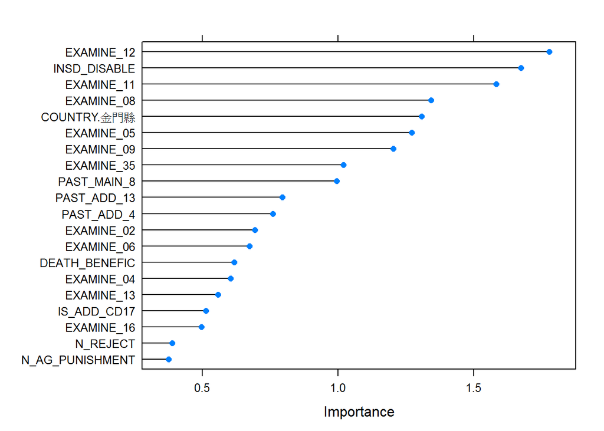

```r
Imp <- varImp(model_glm, scale = FALSE)
plot(Imp, top = 20)
```

- 儲存模型 RDS 檔在 Model 資料夾內。

```r
saveRDS(model_glm, './Model/model_glm.rds')
```

## 3.2 Decision Tree model

- 決策樹是最基礎的 Tree-based Models ，以樹狀分支的結構建立分類規則。
- 以下用 rpart 函數示範，詳細可以看 rpart。

```r
model_tree = train(x = Train_X,
                   y = Train_Y,
                   method = "rpart",
                   trControl = fitControl
                   )

model_tree
```

```
## CART
##
## 40000 samples
##   138 predictor
##     2 classes: 'N', 'Y'
##
## No pre-processing
## Resampling: Cross-Validated (4 fold)
## Summary of sample sizes: 30000, 30000, 30000, 30000
## Resampling results across tuning parameters:
##
##   cp          Accuracy  Kappa
##   0.01526909  0.735375  0.42029242
##   0.06830413  0.706075  0.33073626
##   0.16414268  0.615725  0.05050598
##
## Accuracy was used to select the optimal model using the largest value.
## The final value used for the model was cp = 0.01526909.
```

- 觀察測試資料預測結果。

```r
Test_pred = predict(model_tree,Test_X,type = "raw") # raw 代表回傳預測結果
Test_pred_score = predict(model_tree,Test_X,type = "prob")[,2] # prob [,2]代表為Y的機率，計算AUC用
pred_CM = confusionMatrix(Test_pred,Test_Y, mode = "prec_recall",positive = "Y") # 計算混淆矩陣
pred_AUC = auc(as.integer(Test_Y)-1,Test_pred_score) # 計算AUC，需要轉數值
performance_tree = list(pred_CM,pred_AUC)
print(performance_tree)
```

```
## [[1]]
## Confusion Matrix and Statistics
##
##           Reference
## Prediction     N     Y
##          N 10501  3038
##          Y 13485 32976
##
##                Accuracy : 0.7246
##                  95% CI : (0.721, 0.7282)
##     No Information Rate : 0.6002
##     P-Value [Acc > NIR] : < 2.2e-16
##
##                   Kappa : 0.3812
##
##  Mcnemar's Test P-Value : < 2.2e-16
##
##               Precision : 0.7098
##                  Recall : 0.9156
##                      F1 : 0.7997
##              Prevalence : 0.6002
##          Detection Rate : 0.5496
##    Detection Prevalence : 0.7743
##       Balanced Accuracy : 0.6767
##
##        'Positive' Class : Y
##
##
## [[2]]
## Area under the curve: 0.6876
```

- 觀察模型前 20 主要影響成分。

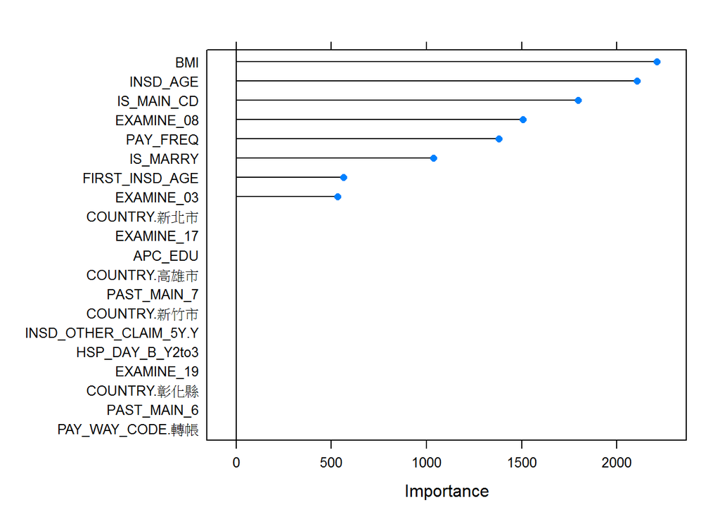

```r
Imp <- varImp(model_tree, scale = FALSE)
plot(Imp, top = 20)
```

- 儲存模型 RDS 檔在 Model 資料夾內。

```r
saveRDS(model_tree, './Model/model_tree.rds')
```

## 3.3 Random Forest model

- 隨機森林是 Tree-based 的一種模型，詳細可以參考 [Random forest](https://en.wikipedia.org/wiki/Random_forest)。
- 以下用 randomForest 函數示範，詳細可以看 randomForest。

```r
model_rf = train(x = Train_X,
                 y = Train_Y,
                 method = "rf",
                 ntree = 10, # Number of trees
                 trControl = fitControl
)

model_rf
```

```
## Random Forest
##
## 40000 samples
##   138 predictor
##     2 classes: 'N', 'Y'
##
## No pre-processing
## Resampling: Cross-Validated (4 fold)
## Summary of sample sizes: 30000, 30000, 30000, 30000
## Resampling results across tuning parameters:
##
##   mtry  Accuracy  Kappa
##     2   0.702425  0.3271140
##    70   0.798100  0.5740700
##   138   0.796425  0.5697564
##
## Accuracy was used to select the optimal model using the largest value.
## The final value used for the model was mtry = 70.
```

- 觀察測試資料預測結果。

```r
Test_pred = predict(model_rf,Test_X,type = "raw") # raw 代表回傳預測結果
Test_pred_score = predict(model_rf,Test_X,type = "prob")[,2] # prob [,2]代表為Y的機率，計算AUC用
pred_CM = confusionMatrix(Test_pred,Test_Y, mode = "prec_recall",positive = "Y") # 計算混淆矩陣
pred_AUC = auc(as.integer(Test_Y)-1,Test_pred_score) # 計算AUC，需要轉數值
performance_rf = list(pred_CM,pred_AUC)
print(performance_rf)
```

```
## [[1]]
## Confusion Matrix and Statistics
##
##           Reference
## Prediction     N     Y
##          N 17142  4973
##          Y  6844 31041
##
##                Accuracy : 0.803
##                  95% CI : (0.7998, 0.8062)
##     No Information Rate : 0.6002
##     P-Value [Acc > NIR] : < 2.2e-16
##
##                   Kappa : 0.5842
##
##  Mcnemar's Test P-Value : < 2.2e-16
##
##               Precision : 0.8193
##                  Recall : 0.8619
##                      F1 : 0.8401
##              Prevalence : 0.6002
##          Detection Rate : 0.5173
##    Detection Prevalence : 0.6314
##       Balanced Accuracy : 0.7883
##
##        'Positive' Class : Y
##
##
## [[2]]
## Area under the curve: 0.871
```

- 觀察模型前 20 主要影響成分。

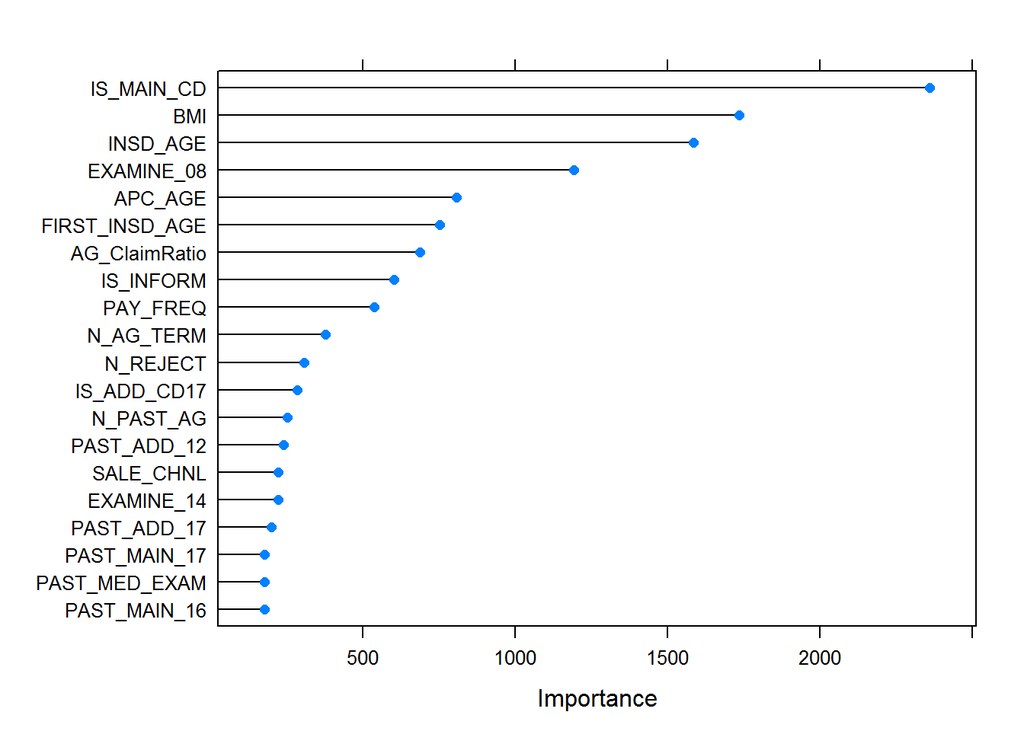

```r
Imp <- varImp(model_rf, scale = FALSE)
plot(Imp, top = 20)
```

- 儲存模型 RDS 檔在 Model 資料夾內。

```r
saveRDS(model_rf, './Model/model_rf.rds')
```

## 3.4 Extra Tree model

- Extra Tree 是類似隨機森林的演算法，差別在於隨機森林應用的是 Bagging 模型，而 Extra Tree 是使用所有的訓練樣本得到每棵決策樹，詳細可以參考 [Random forest vs extra trees](https://www.thekerneltrip.com/statistics/random-forest-vs-extra-tree/)。

```r
model_et = train(x = Train_X,
                 y = Train_Y,
                 method = "extraTrees",
                 ntree = 10,
                 trControl = fitControl
)

model_et
```

```
## Random Forest by Randomization
##
## 40000 samples
##   138 predictor
##     2 classes: 'N', 'Y'
##
## No pre-processing
## Resampling: Cross-Validated (4 fold)
## Summary of sample sizes: 30000, 30000, 30000, 30000
## Resampling results across tuning parameters:
##
##   mtry  numRandomCuts  Accuracy  Kappa
##     2   1              0.718975  0.4135803
##     2   2              0.725600  0.4283931
##     2   3              0.732125  0.4425103
##    70   1              0.789725  0.5645424
##    70   2              0.794450  0.5736647
##    70   3              0.792950  0.5708074
##   138   1              0.789950  0.5642489
##   138   2              0.792225  0.5688379
##   138   3              0.788675  0.5611255
##
## Accuracy was used to select the optimal model using the largest value.
## The final values used for the model were mtry = 70 and numRandomCuts = 2.
```

- 觀察測試資料預測結果。

```r
Test_pred = predict(model_et,Test_X,type = "raw") # raw 代表回傳預測結果
Test_pred_score = predict(model_et,Test_X,type = "prob")[,2] # prob [,2]代表為Y的機率，計算AUC用
pred_CM = confusionMatrix(Test_pred,Test_Y, mode = "prec_recall",positive = "Y") # 計算混淆矩陣
pred_AUC = auc(as.integer(Test_Y)-1,Test_pred_score) # 計算AUC，需要轉數值
performance_et = list(pred_CM,pred_AUC)
print(performance_et)
```

```
## [[1]]
## Confusion Matrix and Statistics
##
##           Reference
## Prediction     N     Y
##          N 18209  6222
##          Y  5777 29792
##
##                Accuracy : 0.8
##                  95% CI : (0.7968, 0.8032)
##     No Information Rate : 0.6002
##     P-Value [Acc > NIR] : < 2.2e-16
##
##                   Kappa : 0.5846
##
##  Mcnemar's Test P-Value : 5.05e-05
##
##               Precision : 0.8376
##                  Recall : 0.8272
##                      F1 : 0.8324
##              Prevalence : 0.6002
##          Detection Rate : 0.4965
##    Detection Prevalence : 0.5928
##       Balanced Accuracy : 0.7932
##
##        'Positive' Class : Y
##
##
## [[2]]
## Area under the curve: 0.8685
```

- 觀察模型前 20 主要影響成分。

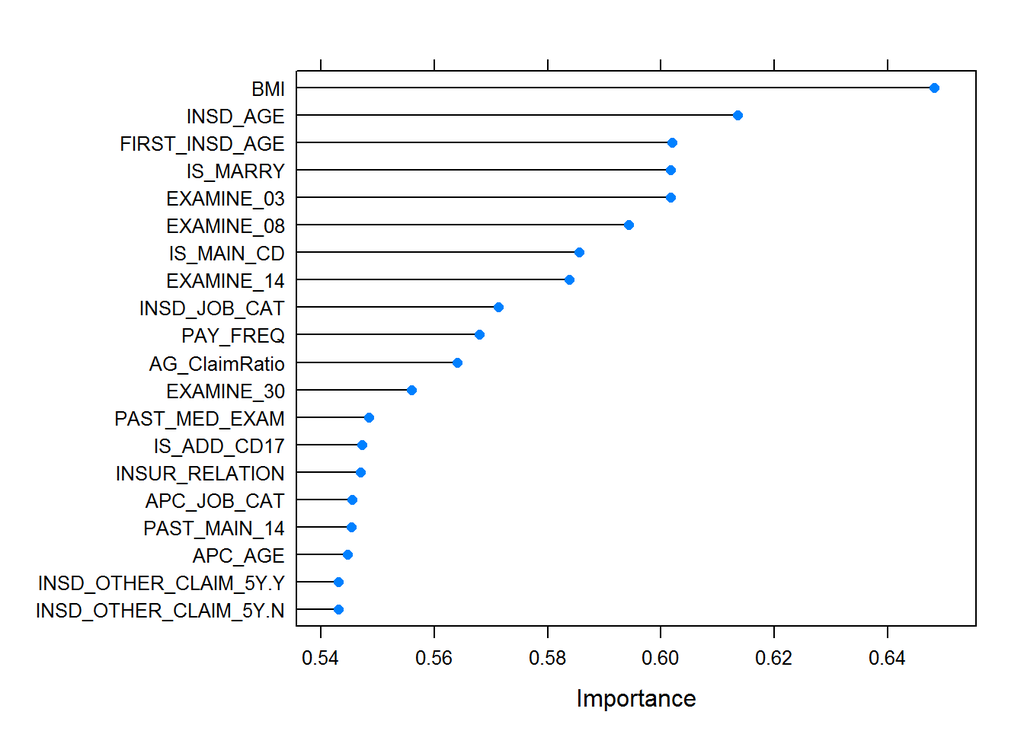

```r
Imp <- varImp(model_et, scale = FALSE)
plot(Imp, top = 20)
```

- 儲存模型 RDS 檔在 Model 資料夾內。

```r
saveRDS(model_et, './Model/model_et.rds')
```

## 3.5 Stochastic Gradient Boosting (GBM)

- 不同於 Bagging 模型， Boosting 模型使用疊代的方式修正錯誤，達到更好的預測效果，也是目前主流的模型架構，詳細可以參考 [Gradient boosting](https://en.wikipedia.org/wiki/Gradient_boosting)。

```r
model_gbm = train(x = Train_X,
                  y = Train_Y,
                  method = "gbm",
                  trControl = fitControl
)
model_gbm
```

```
## Stochastic Gradient Boosting
##
## 40000 samples
##   138 predictor
##     2 classes: 'N', 'Y'
##
## No pre-processing
## Resampling: Cross-Validated (4 fold)
## Summary of sample sizes: 30000, 30000, 30000, 30000
## Resampling results across tuning parameters:
##
##   interaction.depth  n.trees  Accuracy  Kappa
##   1                   50      0.735525  0.4085450
##   1                  100      0.754200  0.4573038
##   1                  150      0.769650  0.4977511
##   2                   50      0.766850  0.4887616
##   2                  100      0.788800  0.5457464
##   2                  150      0.797925  0.5687312
##   3                   50      0.787025  0.5393316
##   3                  100      0.803100  0.5801140
##   3                  150      0.806525  0.5888484
##
## Tuning parameter 'shrinkage' was held constant at a value of 0.1
##
## Tuning parameter 'n.minobsinnode' was held constant at a value of 10
## Accuracy was used to select the optimal model using the largest value.
## The final values used for the model were n.trees = 150,
##  interaction.depth = 3, shrinkage = 0.1 and n.minobsinnode = 10.
```

- 觀察測試資料預測結果。

```r
Test_pred = predict(model_gbm,Test_X,type = "raw") # raw 代表回傳預測結果
Test_pred_score = predict(model_gbm,Test_X,type = "prob")[,2] # prob [,2]代表為Y的機率，計算AUC用
pred_CM = confusionMatrix(Test_pred,Test_Y, mode = "prec_recall",positive = "Y") # 計算混淆矩陣
pred_AUC = auc(as.integer(Test_Y)-1,Test_pred_score) # 計算AUC，需要轉數值
performance_gbm = list(pred_CM,pred_AUC)
print(performance_gbm)
```

```
## [[1]]
## Confusion Matrix and Statistics
##
##           Reference
## Prediction     N     Y
##          N 16724  4229
##          Y  7262 31785
##
##                Accuracy : 0.8085
##                  95% CI : (0.8053, 0.8116)
##     No Information Rate : 0.6002
##     P-Value [Acc > NIR] : < 2.2e-16
##
##                   Kappa : 0.5923
##
##  Mcnemar's Test P-Value : < 2.2e-16
##
##               Precision : 0.8140
##                  Recall : 0.8826
##                      F1 : 0.8469
##              Prevalence : 0.6002
##          Detection Rate : 0.5298
##    Detection Prevalence : 0.6508
##       Balanced Accuracy : 0.7899
##
##        'Positive' Class : Y
##
##
## [[2]]
## Area under the curve: 0.8785
```

- 觀察模型前 20 主要影響成分。

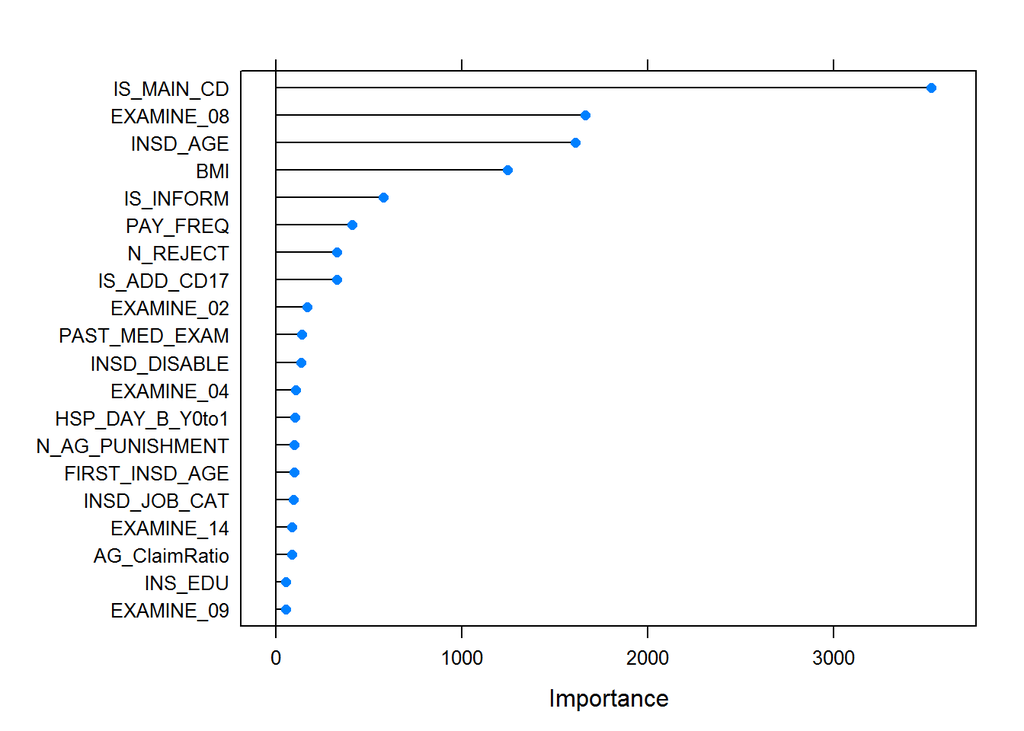

```r
Imp <- varImp(model_gbm, scale = FALSE)
plot(Imp, top = 20)
```

- 儲存模型 RDS 檔在 Model 資料夾內。

```r
saveRDS(model_gbm, './Model/model_gbm.rds')
```

## 3.6 eXtreme Gradient Boosting model (XGBoost)

- XGBoost 是目前最流行的演算法之一，訓練快速且準確率高，詳細可以參考 XGBoost。
- XGBoost 可以調整的參數眾多，為了為了避免訓練時間過長，先以下面語法簡單示範。

```r
tune_grid = expand.grid(nrounds = 200,
                        max_depth = 5,
                        eta = 0.1,
                        gamma = 0.01,
                        colsample_bytree = 0.75,
                        min_child_weight = 0,
                        subsample = 0.5)


model_xgb = train(x = Train_X,
                  y = Train_Y,
                  method = "xgbTree",
                  tuneGrid = tune_grid,
                  tuneLength = 10, # 每個參數調整的範圍，避免訓練太久先設10
                  trControl = fitControl
)

model_xgb
```

[output not shown]

- 觀察測試資料預測結果。

```r
Test_pred = predict(model_xgb,Test_X,type = "raw") # raw 代表回傳預測結果
Test_pred_score = predict(model_xgb,Test_X,type = "prob")[,2] # prob [,2]代表為Y的機率，計算AUC用
pred_CM = confusionMatrix(Test_pred,Test_Y, mode = "prec_recall",positive = "Y") # 計算混淆矩陣
pred_AUC = auc(as.integer(Test_Y)-1,Test_pred_score) # 計算AUC，需要轉數值
performance_xgb = list(pred_CM,pred_AUC)
print(performance_xgb)
```

```
## [[1]]
## Confusion Matrix and Statistics
##
##           Reference
## Prediction     N     Y
##          N 17287  3783
##          Y  6699 32231
##
##                Accuracy : 0.8253
##                  95% CI : (0.8222, 0.8283)
##     No Information Rate : 0.6002
##     P-Value [Acc > NIR] : < 2.2e-16
##
##                   Kappa : 0.6284
##
##  Mcnemar's Test P-Value : < 2.2e-16
##
##               Precision : 0.8279
##                  Recall : 0.8950
##                      F1 : 0.8601
##              Prevalence : 0.6002
##          Detection Rate : 0.5372
##    Detection Prevalence : 0.6488
##       Balanced Accuracy : 0.8078
##
##        'Positive' Class : Y
##
##
## [[2]]
## Area under the curve: 0.8978
```

- 觀察模型前 20 主要影響成分。

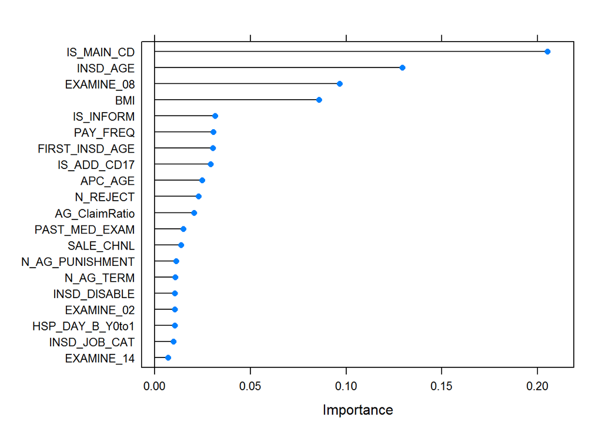

```r
Imp <- varImp(model_xgb, scale = FALSE)
plot(Imp, top = 20)
```

- 儲存模型 RDS 檔在 Model 資料夾內。

```r
saveRDS(model_xgb, './Model/model_xgb.rds')
```

## 3.7 模型比較

- caret 支援的演算法眾多，本教材僅用上述 6 個做示範，詳細可以參考 [Available Models](https://topepo.github.io/caret/available-models.html)。
- 使用多個演算法建模後，會比較各個演算法的表現能力，選擇最好的當作最終模型，以下用繪圖方式顯示模型的AUC比較。

```r
Algorithm = c('GLM','TREE','RF','ExTree','GBM','XGB')
AUC_tmp = NULL
# 測試資料的AUC表現
# glm
Test_pred_score = predict(model_glm,Test_X,type = "prob")[,2]
AUC_tmp[1] = auc(as.integer(Test_Y)-1,Test_pred_score)[1]
# Decision Tree
Test_pred_score = predict(model_tree,Test_X,type = "prob")[,2]
AUC_tmp[2] = auc(as.integer(Test_Y)-1,Test_pred_score)[1]
# Random Forest
Test_pred_score = predict(model_rf,Test_X,type = "prob")[,2]
AUC_tmp[3] = auc(as.integer(Test_Y)-1,Test_pred_score)[1]
# Extra Tree
Test_pred_score = predict(model_et,Test_X,type = "prob")[,2]
AUC_tmp[4] = auc(as.integer(Test_Y)-1,Test_pred_score)[1]
# GBM
Test_pred_score = predict(model_gbm,Test_X,type = "prob")[,2]
AUC_tmp[5] = auc(as.integer(Test_Y)-1,Test_pred_score)[1]
# XGBoost
Test_pred_score = predict(model_xgb,Test_X,type = "prob")[,2]
AUC_tmp[6] = auc(as.integer(Test_Y)-1,Test_pred_score)[1]

Test_AUC = data.frame(t(AUC_tmp))
colnames(Test_AUC) = Algorithm
print(Test_AUC)
```

```
##         GLM      TREE        RF    ExTree       GBM       XGB
## 1 0.7988567 0.6876046 0.8709613 0.8685056 0.8785382 0.8977827
```

- 根據結果以 XGBoost 的模型表現力最好，可以使用該模型進行深入校調。
- 許多時候測試資料是沒有答案可以驗收的，可以從訓練資料切一部分保留，當成測試資料使用。

# 4. **原生套件示範**

- 使用原生套件的靈活度較高，但相對自己要設定的東西也比較多，以表現力最好的 XGBoost 為例，我們使用以下語法建模。

```r
library(caret)
library(xgboost)

# 原生套件只能吃 integer 格式
Train_Y_tmp = as.integer(Train_Y)-1
Test_Y_tmp = as.integer(Test_Y)-1

nfold = 4 # 建立 fold 數
set.seed(1001)
folds = createFolds(factor(Train_Y_tmp), k = nfold, list = FALSE)

dev_result =  rep(0, nrow(Train_X)) # 建立空向量放 valid 答案
pred_te = rep(0, nrow(Test_X)) # 建立空向量放 test 答案
```

```r
# 透過 for 迴圈跑 valid
for (this.round in 1:nfold){
  valid = c(1:length(Train_Y_tmp)) [folds == this.round] # valid index
  dev = c(1:length(Train_Y_tmp)) [folds != this.round] # train index

  dtrain= xgb.DMatrix(data= as.matrix(Train_X[dev,]),
                       label= Train_Y_tmp[dev])
  dvalid = xgb.DMatrix(data= as.matrix(Train_X[valid,]) ,
                        label= Train_Y_tmp[valid])

  # 設定參數
  param = list(objective = "binary:logistic",
               eval_metric = "auc",
               max_depth = 10,
               eta = 0.01,
               gamma = 0,
               subsample = 0.8,
               colsample_bytree = 0.8,
               min_child_weight = 8,
               colsample_bylevel = 0.8,
               lambda = 1,
               alpha = 0,
               booster = "gbtree",
               silent = 0
  )

  # 開始訓練
  model =  xgb.train(data = dtrain,
                    params= param,
                    nrounds = 5000,
                    verbose = T,
                    list(val1=dtrain , val2 = dvalid) ,
                    early_stopping_rounds = 50 ,
                    print_every_n = 10,
                    maximize = T
  )

  # 將每個 fold 的 model 儲存
  saveRDS(model, file = paste0("./Model/xgb_",this.round,".rda"))
  pred = predict(model,as.matrix(Train_X[valid,]))
  dev_result[valid] = pred
  pred_test  = predict(model,as.matrix(Test_X))
  pred_te = pred_te +pred_test
}
```

[output not shown]

- 實際執行會發現，即使樹的深度更深，原生套件的訓練速度並沒有比較慢，效能更好。
- 觀察測試資料的預測能力，因為樹的深度更深，疊代次數增加，模型訓練的 AUC 更好一點。

```r
library(pROC)
pred_test = pred_te/nfold
auc(Test_Y_tmp,pred_test)
```

```
## Area under the curve: 0.9015
```

- 因為是分類預測，我們建立一個 threshold 函數來找出最佳閥值，切割我們的預測結果，高於 threshold 為 Y ，低於為 N。

```r
threshold <- function(predict, response) {
  r <- pROC::roc(response, predict)
  r$thresholds[which.max(r$sensitivities + r$specificities)]
}

# 找出最佳閥值，如果測試資料沒有答案的話就沒有 test_threshold
train_threshold = threshold(dev_result,Train_Y_tmp)
test_threshold = threshold(pred_test,Test_Y_tmp)
cat("valid threshold：",train_threshold,"; testdata threshold：",test_threshold)
```

```
## valid threshold： 0.6052935 ; testdata threshold： 0.6179254
```

- 以 testdata threshold 為閥值進行切割，混淆矩陣如下。

```r
Pred_Y = ifelse(pred_test > test_threshold,'1','0')
confusionMatrix(factor(Pred_Y),factor(Test_Y_tmp), mode = "prec_recall",positive = "1")
```

```
## Confusion Matrix and Statistics
##
##           Reference
## Prediction     0     1
##          0 19317  6255
##          1  4669 29759
##
##                Accuracy : 0.8179
##                  95% CI : (0.8148, 0.821)
##     No Information Rate : 0.6002
##     P-Value [Acc > NIR] : < 2.2e-16
##
##                   Kappa : 0.6248
##
##  Mcnemar's Test P-Value : < 2.2e-16
##
##               Precision : 0.8644
##                  Recall : 0.8263
##                      F1 : 0.8449
##              Prevalence : 0.6002
##          Detection Rate : 0.4960
##    Detection Prevalence : 0.5738
##       Balanced Accuracy : 0.8158
##
##        'Positive' Class : 1
##
```

- 顯示模型前 20 主要影響成分。

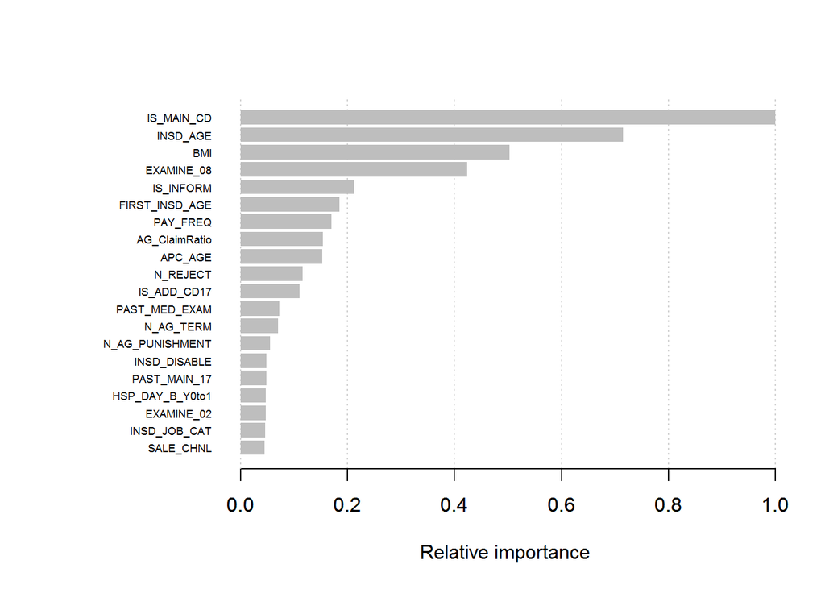

```r
importance_matrix <- xgb.importance(colnames(Train_X), model = model)
xgb.plot.importance(importance_matrix, rel_to_first = TRUE, xlab = "Relative importance",top = 20)
```

**資料特徵及品質才是模型預測力提升的主要關鍵，演算法及參數調整只是逼近上限而已，如果預測結果不如預期，務必回到資料工程步驟，重新檢視再訓練，請記住自己是資料科學家而不是演算法套用家。**